# Chapter 8 Firms in the Global Economy: Export Decisions, Outsourcing, and Multinational Enterprises

# Preview

- Monopolistic competition and trade
- The significance of intra-industry trade
- Firm responses to trade: winners, losers, and industry performance
- Dumping
- Multinationals and outsourcing

# The Theory of Imperfect Competition

# Introduction

- When economies of scale exist, large firms may be more efficient than small firms, and the industry may consist of a monopoly or a few large firms.
  - Production may be imperfectly competitive in the sense that excess or monopoly profits are captured by large firms.
- Internal economies of scale result when large firms have a cost advantage over small firms, causing the industry to become uncompetitive.

# Introduction

- Internal economies of scale imply that a firm’s average cost of production decreases the more output it produces.
- Perfect competition that drives the price of a good down to marginal cost would imply losses for those firms because they would not be able to recover the higher costs incurred from producing the initial units of output.
- As a result, perfect competition would force those firms out of the market.

# Introduction

- In most sectors, goods are differentiated from each other and there are other differences across firms.
- Integration causes the better-performing firms to thrive and expand, while the worse-performing firms contract.
- Additional source of gain from trade: As production is concentrated toward better-performing firms, the overall efficiency of the industry improves.
- Study why those better-performing firms have a greater incentive to engage in the global economy.

# The Theory of Imperfect Competition

- In imperfect competition, firms are aware that they can influence the prices of their products and that they can sell more only by reducing their price.
- This situation occurs when there are only a few major producers of a particular good or when each firm produces a good that is differentiated from that of rival firms.
- Each firm views itself as a price setter, choosing the price of its product.

# Monopoly: A Brief Review

- A **monopoly** is an industry with only one firm.
- An **oligopoly** is an industry with only a few firms.
- In these industries, the marginal revenue generated from selling more products is less than the uniform price charged for each product.
  - To sell more, a firm must lower the price of all units, not just the additional ones.
  - The marginal revenue function therefore lies below the demand function (which determines the price that customers are willing to pay).

# Monopoly: A Brief Review

- Assume that the **demand curve** the firm faces is a straight line $Q = A – B(P)$, where $Q$ is the number of units the firm sells, $P$ the price per unit, and $A$ and $B$ are constants.
- **Marginal revenue** equals $MR = P – Q/B$.
- Suppose that **total costs** are $C = F + c(Q)$, where $F$ is fixed costs, those independent of the level of output, and $c$ is the constant marginal cost.

# Monopolistic Pricing and Production Decisions

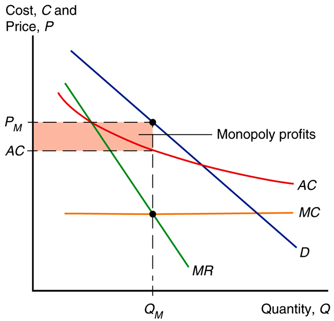

# Monopoly: A Brief Review

- **Average cost** is the cost of production ($C$) divided by the total quantity of production ($Q$). $AC = C/Q = F/Q + c$
- **Marginal cost** is the cost of producing an additional unit of output.
- A larger firm is more efficient because average cost decreases as output $Q$ increases: internal economies of scale.

# AC Versus MC

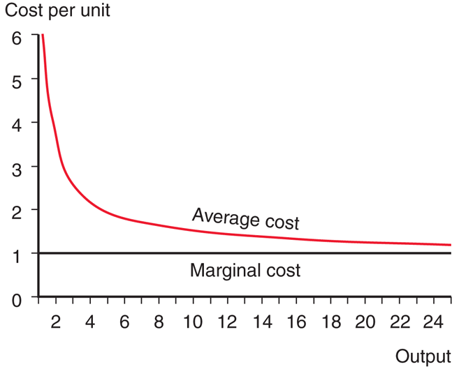

# Monopoly: A Brief Review

- The profit-maximizing output occurs where marginal revenue equals marginal cost.
  - At the intersection of the MC and MR curves, the revenue gained from selling an extra unit equals the cost of producing that unit.
- The monopolist earns some monopoly profits, as indicated by the shaded box, when $P>AC$.

# Monopolistic Competition

- **Monopolistic competition** is a simple model of an imperfectly competitive industry that assumes that each firm
  1. can differentiate its product from the product of competitors, and
  2. takes the prices charged by its rivals as given.

# Monopolistic Competition

# Monopolistic Competition

$Q = S[1/n – b(P – \bar{P})]$

- $Q$ is an individual firm’s sales
- $S$ is the total sales of the industry
- $n$ is the number of firms in the industry
- $b$ is a constant term representing the responsiveness of a firm’s sales to its price
- $P$ is the price charged by the firm itself
- $\bar{P}$ is the average price charged by its competitors

# Monopolistic Competition

- Assume that firms are symmetric: all firms face the same demand function and have the same cost function.
  - Thus all firms should charge the same price and have equal share of the market $Q = S/n$
  - Average costs should depend on the size of the market and the number of firms: $AC = C/Q = F/Q + c = n F/S + c$

# Monopolistic Competition

$AC = n(F/S) + c$

- As the number of firms n in the industry increases, the average cost increases for each firm because each produces less.
- As total sales S of the industry increase, the average cost decreases for each firm because each produces more.

# Equilibrium in a Monopolistically Competitive Market

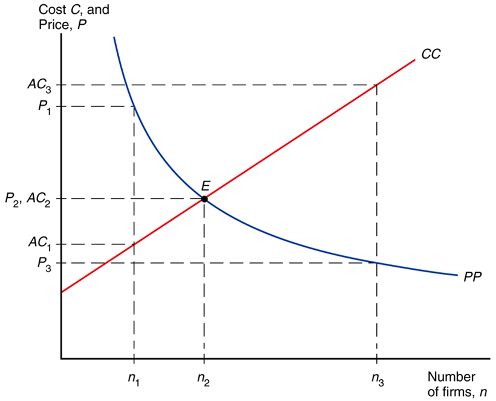

# Monopolistic Competition

- If monopolistic firms face linear demand functions, $Q = A – B(P)$,
  - where A and B are constants.
- When firms maximize profits, they should produce until marginal revenue equals marginal cost: $MR = P – Q/B = c$
- As the number of firms $n$ in the industry increases, the price that each firm charges decreases because of increased competition.

# Monopolistic Competition

- At some number of firms, the price that firms charge (which decreases in $n$) matches the average cost that firms pay (which increases in $n$).
- At this long-run equilibrium number of firms in the industry, firms have no incentive to enter or exit the industry.

# Monopolistic Competition

- If the number of firms is greater than or less than the equilibrium number, then firms have an incentive to exit or enter the industry.
  - Firms have an incentive to exit the industry when price < average cost.
  - Firms have an incentive to enter the industry when price > average cost.

# Monopolistic Competition and Trade

# Monopolistic Competition and Trade

- Because trade increases market size, trade is predicted to decrease average cost in an industry described by monopolistic competition.
  - Industry sales increase with trade leading to decreased average costs: $AC = n(F/S) + c$
- Because trade increases the variety of goods that consumers can buy under monopolistic competition, it increases the welfare of consumers.
  - And because average costs decrease, consumers can also benefit from a decreased price.

# Effects of a Larger Market

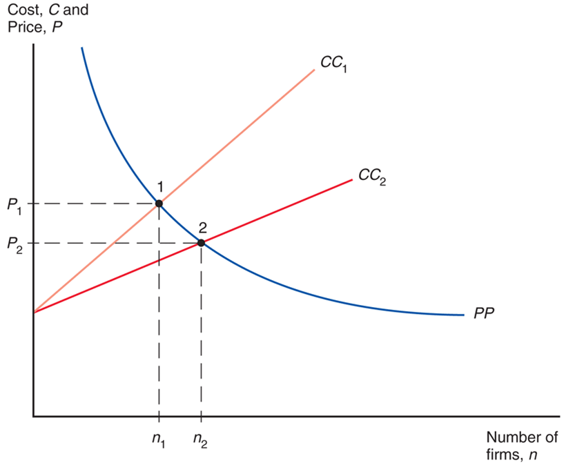

# Monopolistic Competition and Trade

- As a result of trade, the number of firms in a new international industry is predicted to increase relative to each national market.
  - But it is unclear if firms will locate in the domestic country or foreign countries.
- Integrating markets through international trade therefore has the same effects as growth of a market within a single country.

# Equilibrium in the Automobile Market

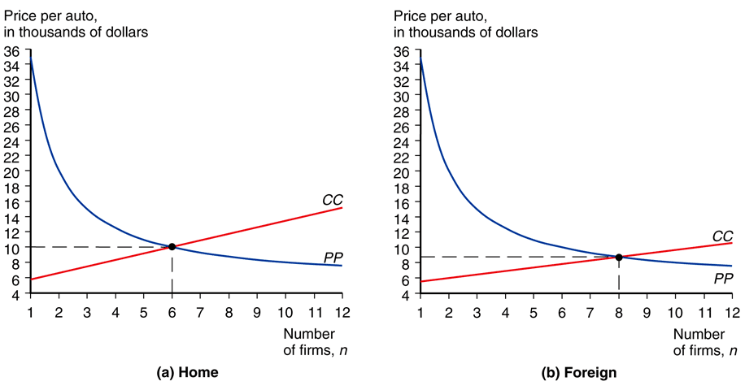

# Equilibrium in the Automobile Market

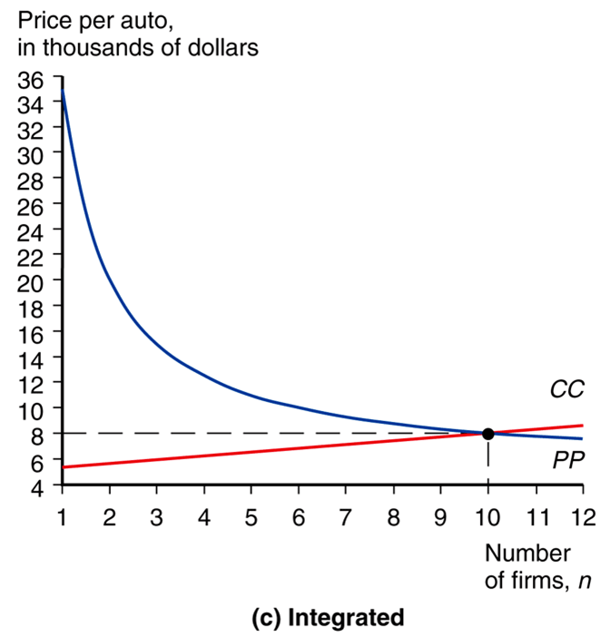

# Hypothetical Example of Gains from Market Integration

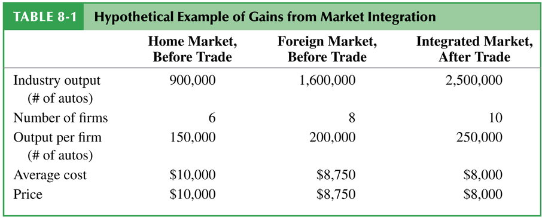

# Monopolistic Competition and Trade

- Product differentiation and internal economies of scale lead to trade between similar countries with no comparative advantage differences between them.
  - This is a very different kind of trade than the one based on comparative advantage, where each country exports its comparative advantage good.

# The Significance of Intra-industry Trade

- **Intra-industry trade** refers to two-way exchanges of similar goods.
- Two new channels for welfare benefits from trade:
  - Benefit from a greater variety at a lower price.
  - Firms consolidate their production and take advantage of economies of scale.
- A smaller country stands to gain more from integration than a larger country.

# The Significance of Intra-industry Trade

- About 25–50% of world trade is intra-industry.
- Most prominent is the trade of manufactured goods among advanced industrial nations, which accounts for the majority of world trade.
  - For the United States, industries that have the most intra-industry trade—such as pharmaceuticals, chemicals, and specialized machinery—require relatively larger amounts of skilled labor, technology, and physical capital.

# Indexes of Intra-Industry Trade for U.S. Industries, 2009

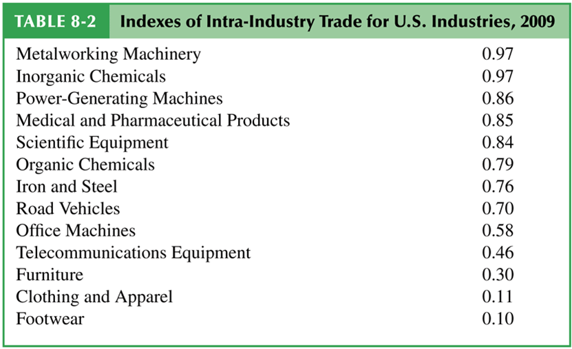

# Firm Responses to Trade: Winners, Losers, and Industry Performance

# Firm Responses to Trade

- Increased competition tends to hurt the worst-performing firms — they are forced to exit.
- The best-performing firms take the greatest advantage of new sales opportunities and expand the most.
- When the better-performing firms expand and the worse-performing ones contract or exit, overall industry performance improves.
  - Trade and economic integration improve industry performance as much as the discovery of a better technology does.

# Performance Differences Across Firms

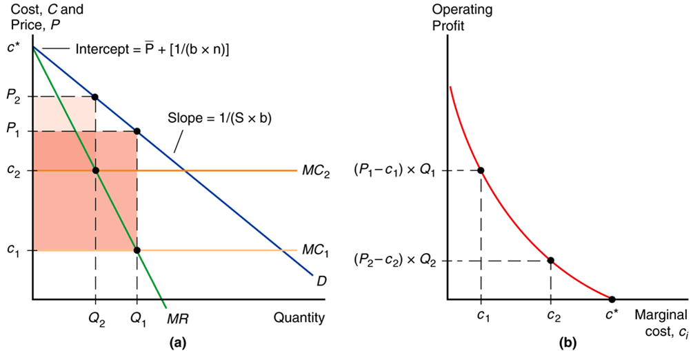

# Winners and Losers from Economic Integration

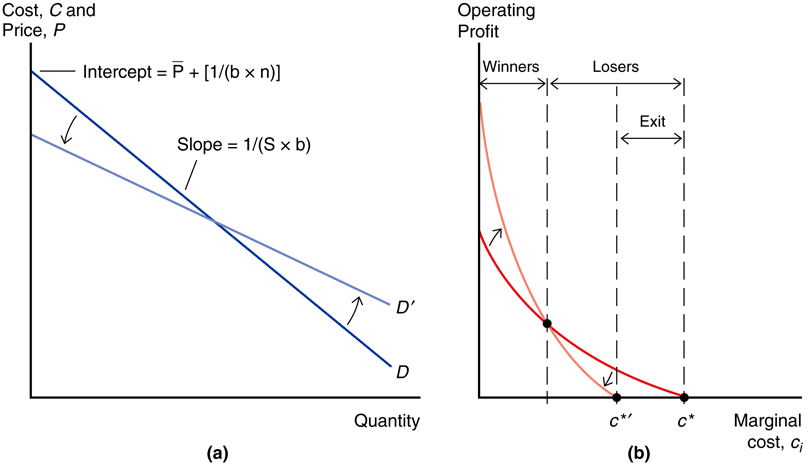

# Trade Costs and Export Decisions

# Trade Costs and Export Decisions

- Most U.S. firms do not report *any* exporting activity at all — sell only to U.S. customers.
  - In 2002, only 18% of U.S. manufacturing firms reported any sales abroad.
- Even in industries that export much of what they produce, such as chemicals, machinery, electronics, and transportation, fewer than 40 percent of firms export.
- A major reason why trade costs reduce trade so much is that they drastically reduce the number of firms selling to customers across the border.
  - Trade costs also reduce the volume of export sales of firms selling abroad.

# Trade Costs and Export Decisions

- Trade costs added two important predictions to our model of monopolistic competition and trade:
  - Why only a subset of firms export, and why exporters are relatively larger and more productive (lower marginal costs).
- Overwhelming empirical support for this prediction that exporting firms are bigger and more productive than firms in the same industry that do not export.
  - In the United States, in a typical manufacturing industry, an exporting firm is on average more than twice as large as a firm that does not export.
  - Differences between exporters and nonexporters are even larger in many European countries.

# Proportion of U.S. Firms Reporting Export Sales by Industry, 2002

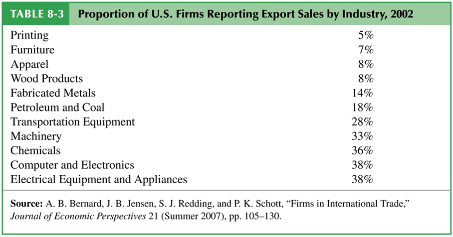

# Export Decisions with Trade Costs

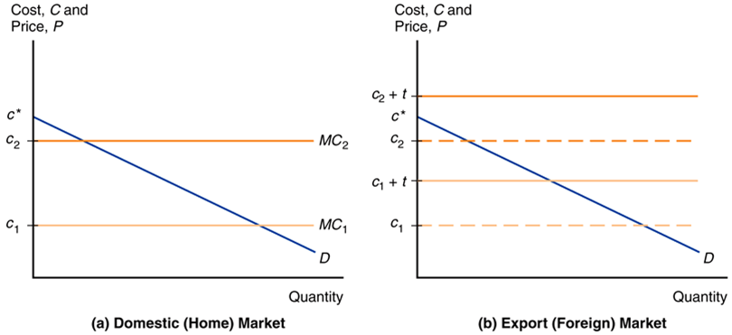

# Dumping

# Dumping

- **Dumping** is the practice of charging a lower price for exported goods than for goods sold domestically.
- Dumping is an example of **price discrimination**: the practice of charging different customers different prices.
- Price discrimination and dumping may occur only if
  - *imperfect competition* exists: firms are able to influence market prices.
  - *markets are segmented* so that goods are not easily bought in one market and resold in another.

# Dumping

- Dumping can be a profit-maximizing strategy:
  - A firm with a higher marginal cost chooses to set a lower markup over marginal cost.
  - Therefore, an exporting firm will respond to the trade cost by lowering its markup for the export market.
  - This strategy is considered to be **dumping**, regarded by most countries as an “unfair” trade practice.

# Protectionism and Dumping

- A U.S. firm may appeal to the Commerce Department to investigate if dumping by foreign firms has injured the U.S. firm.
  - The Commerce Department may impose an “anti-dumping duty” (tax) to protect the U.S. firm.
  - Tax equals the difference between the actual and “fair” price of imports, where “fair” means “price the product is normally sold at in the manufacturer’s domestic market.”

# Protectionism and Dumping

- Next, the International Trade Commission (ITC) determines if injury to the U.S. firm has occurred or is likely to occur.
- If the ITC determines that injury has occurred or is likely to occur, the anti-dumping duty remains in place.
  - http://www.usitc.gov/trade_remedy/

# Protectionism and Dumping

- Most economists believe that the enforcement of dumping claims is misguided.
  - Trade costs have a natural tendency to induce firms to lower their markups in export markets.
  - Such enforcement may be used excessively as an excuse for protectionism.

# Multinationals and Outsourcing

# Multinationals and Outsourcing

- **Foreign direct investment** refers to investment in which a firm in one country *directly controls or owns* a subsidiary in another country.
- If a foreign company invests in at least 10% of the stock in a subsidiary, the two firms are typically classified as a **multinational corporation**.
  - 10% or more of ownership in stock is deemed to be sufficient for direct control of business operations.

# Multinationals and Outsourcing

- *Greenfield* FDI is when a company builds a new production facility abroad.
- *Brownfield* FDI (or cross-border mergers and acquisitions) is when a domestic firm buys a controlling stake in a foreign firm.
- Greenfield FDI has tended to be more stable, while cross-border mergers and acquisitions tend to occur in surges.

# Multinationals and Outsourcing

- Developed countries have been the biggest recipients of inward FDI.
  - much more volatile than FDI going to developing and transition economies.
- Steady expansion in the share of FDI flowing to developing and transition countries.
  - Accounted for half of worldwide FDI flows in 2009.
- Sales of FDI affiliates are often used as a measure of multinational activity.

# Inflows of FDI, 1980-2009

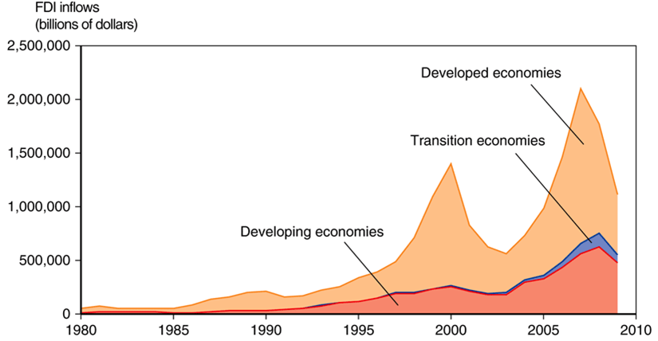

# Multinationals and Outsourcing

- Two main types of FDI:
  - **Horizontal FDI** when the affiliate replicates the production process (that the parent firm undertakes in its domestic facilities) elsewhere in the world.
  - **Vertical FDI** when the production chain is broken up, and parts of the production processes are transferred to the affiliate location.

# Multinationals and Outsourcing

- Vertical FDI is mainly driven by production cost differences between countries (for those parts of the production process that can be performed in another location).
  - Vertical FDI is growing fast and is behind the large increase in FDI inflows to developing countries.

# Multinationals and Outsourcing

- Horizontal FDI is dominated by flows between developed countries.
  - Both the multinational parent and the affiliates are usually located in developed countries.
- The main reason for this type of FDI is to locate production near a firm’s large customer bases.
  - Hence, trade and transport costs play a much more important role than production cost differences for these FDI decisions.

# Outward FDI for Top Countries, 2007-2009

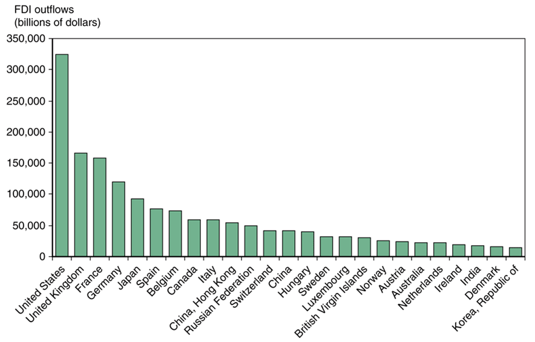

# The Firm’s Decision Regarding Foreign Direct Investment

- *Proximity-concentration* trade-off:
  - High trade costs associated with exporting create an incentive to locate production near customers.
  - Increasing returns to scale in production create an incentive to concentrate production in fewer locations.

# The Firm’s Decision Regarding Foreign Direct Investment

- FDI activity concentrated in sectors with high trade costs.
  - When increasing returns to scale are important and average plant sizes are large, we observe higher export volumes relative to FDI.
- Multinationals tend to be much larger and more productive than other firms (even exporters) in the same country.

# The Firm’s Decision Regarding Foreign Direct Investment

- The horizontal FDI decision involves a trade-off between the per-unit export cost $t$ and the fixed cost $F$ of setting up an additional production facility.
- If $t(Q) > F$, costs more to pay trade costs $t$ on $Q$ units sold abroad than to pay fixed cost $F$ to build a plant abroad.
  - When foreign sales large $Q > F/t$, exporting is more expensive and FDI is the profit-maximizing choice.
  - Low costs make more apt to choose FDI due to larger sales.

# The Firm’s Decision Regarding Foreign Direct Investment

- The vertical FDI decision also involves a trade-off between cost savings and the fixed cost $F$ of setting up an additional production facility.
  - Cost savings related to comparative advantage make some stages of production cheaper in other countries.

# The Firm’s Decision Regarding Foreign Direct Investment

- Foreign **outsourcing** or **offshoring** occurs when a firm contracts with an independent firm to produce in the foreign location.
  - In addition to deciding the **location** of where to produce, firms also face an **internalization** decision: whether to keep production done by one firm or by separate firms.
- Internalization occurs when it is more profitable to conduct transactions and production within a single organization. Reasons for this include:

# The Firm’s Decision Regarding Foreign Direct Investment

1. **Technology transfers**: transfer of knowledge or another form of technology may be easier within a single organization than through a market transaction between separate organizations.
   - Patent or property rights may be weak or nonexistent.
   - Knowledge may not be easily packaged and sold.

# The Firm’s Decision Regarding Foreign Direct Investment

2. **Vertical integration** involves consolidation of different stages of a production process.
   - Consolidating an input within the firm using it can avoid holdup problems and hassles in writing complete contracts.
   - But an independent supplier could benefit from economies of scale if it performs the process for many parent firms.

# The Firm’s Decision Regarding Foreign Direct Investment

- Foreign direct investment should benefit the countries involved for reasons similar to why international trade generates gains.
  - Multinationals and firms that outsource take advantage of cost differentials that favor moving production (or parts thereof) to particular locations.
  - FDI is very similar to the relocation of production that occurred across sectors when opening to trade.
  - There are similar welfare consequences for the case of multinationals and outsourcing: Relocating production to take advantage of cost differences leads to overall gains from trade.

# Summary

# Summary

1. Internal economies of scale imply that more production at the firm level causes average costs to fall.
2. With monopolistic competition, each firm can raise prices somewhat above those on competing products due to product differentiation but must compete with other firms whose prices are believed to be unaffected by each firm’s actions.
3. Monopolistic competition allows for gains from trade through lower costs and prices, as well as through wider consumer choice.
4. Monopolistic competition predicts intra-industry trade, and does not predict changes in income distribution within a country.

# Summary

5. Location of firms under monopolistic competition is unpredictable, but countries with similar relative factors are predicted to engage in intra-industry trade.
6. Dumping may be a profitable strategy when a firm faces little competition in its domestic market and faces heavy competition in foreign markets.
7. Multinationals are typically larger and more productive than exporters, which in turn are larger and more efficient than firms that sell only to the domestic market.

# Summary

8. Multinational corporations undertake foreign direct investment when proximity is more important than concentrating production in one location.
   - Firms produce where it is most cost-effective — abroad if the scale is large enough. They replicate entire production process abroad or locate stages in different countries.
   - Firms also decide whether to keep transactions within the firm or contract with another firm.